# DSCI 6607 ASSIGNMENT

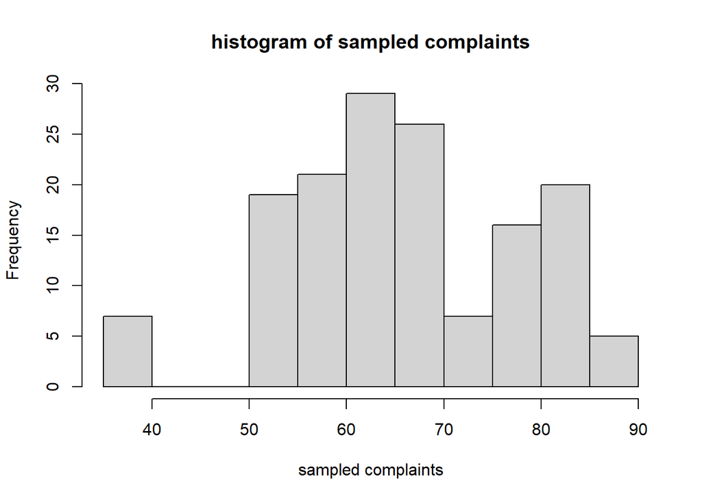

```r
hist(data_s$complaints, main = "histogram of sampled complaints", xlab = "sampled complaints")
```

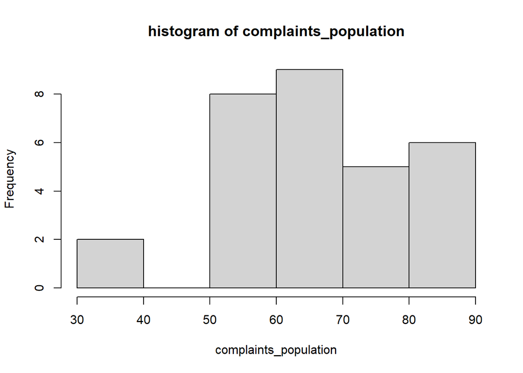

```r
hist(data$complaints, main = "histogram of complaints_population", xlab = "complaints_population")
```

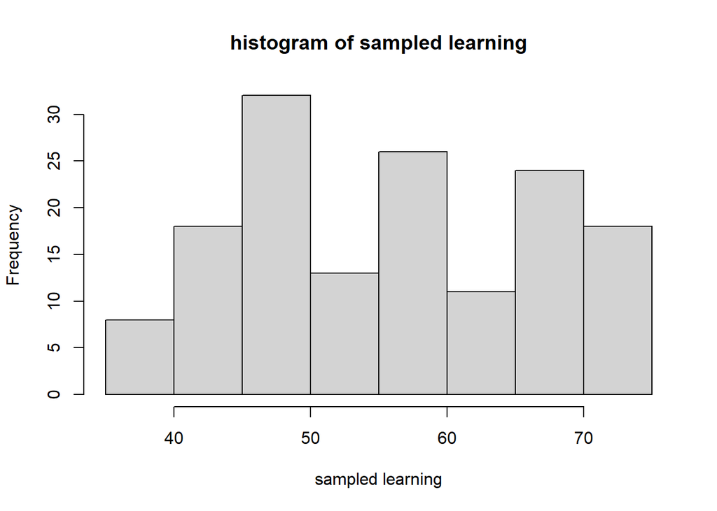

```r
hist(data_s$learning, main = "histogram of sampled learning", xlab = "sampled learning")
```

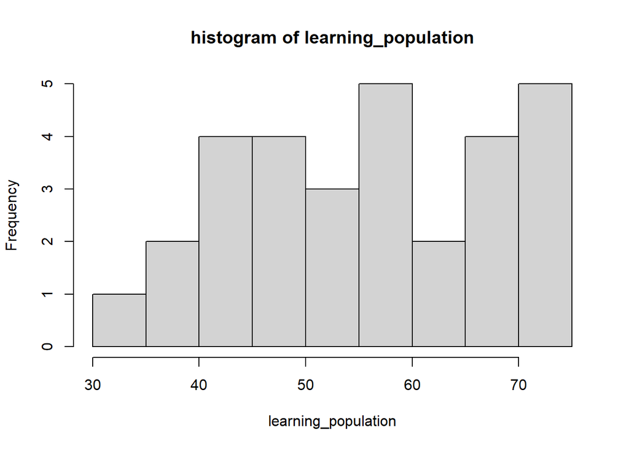

```r
hist(data$learning, main = "histogram of learning_population", xlab = "learning_population")
```

Question 8 Find all numbers not greater than 10,000 that are divisible by 5,7, and 11 and print them.

```r
n <- 1
while( n < 10000)
{
   if(n %% 5 == 0 && n %% 7 == 0 && n %% 11 == 0){
        print(n)
        }
        n <- n + 1
}
```

```
## [1] 385
## [1] 770
## [1] 1155
## [1] 1540
## [1] 1925
## [1] 2310
## [1] 2695
## [1] 3080
## [1] 3465
## [1] 3850
## [1] 4235
## [1] 4620
## [1] 5005
## [1] 5390
## [1] 5775
## [1] 6160
## [1] 6545
## [1] 6930
## [1] 7315
## [1] 7700
## [1] 8085
## [1] 8470
## [1] 8855
## [1] 9240
## [1] 9625
```

Question 9 Print for each of the numbers x = 2, . . . , 20, all numbers that divide x (all factors) excluding 1 and x. For example, for 18, it should print 2 3 6 9.

```r
for (i in 2:20){
  fac <- c()
  for (j in 2:i) {
    if(i%%j==0 && j!=1 && j!=i){
      fac<-c(fac,j)
      }
  }
  cat("factors of", i, "are", fac, "\n")
}
```

```
## factors of 2 are
## factors of 3 are
## factors of 4 are 2
## factors of 5 are
## factors of 6 are 2 3
## factors of 7 are
## factors of 8 are 2 4
## factors of 9 are 3
## factors of 10 are 2 5
## factors of 11 are
## factors of 12 are 2 3 4 6
## factors of 13 are
## factors of 14 are 2 7
## factors of 15 are 3 5
## factors of 16 are 2 4 8
## factors of 17 are
## factors of 18 are 2 3 6 9
## factors of 19 are
## factors of 20 are 2 4 5 10
```

Question 10 Write a function that takes in a data set as an input, returns a list including the column names, the dimensions of the data and the range of variables. Then apply your function to sleep data set. [10 points] # library(datasets) head(sleep)

```r
library(datasets)
#attach(sleep)

myfunction <- function(a){
  y <- as.vector(a)
  mylist <- list(colnames(a), dim(a), range(y))
   return(mylist)

}
myfunction(sleep)
```

```
## [[1]]
## [1] "extra" "group" "ID"
##
## [[2]]
## [1] 20  3
##
## [[3]]
## [1] -1.6 10.0
```